# TCGA preparation

Joaquim Aguirre-Plans

3/9/2022

## Description

Analyze TCGA dataset from GDC.

```r
library(data.table)
library(dplyr)
library(forcats)
library(ggplot2)
require(magrittr)
library(tidyr)
library(igraph)
library(rjson)
set.seed(1510)
`%ni%` <- Negate(`%in%`)
```

```r
# Define type of counts used
type_counts = "tpm" # tpm, reads

# Define working directories
gdc_dir = '/work/ccnr/j.aguirreplans/Databases/TCGA/2022-07-27-Dataset/TCGA'
input_dir = paste(gdc_dir, 'raw', sep='/')
data_dir = paste(input_dir, 'data', sep='/')
metadata_dir = paste(input_dir, 'metadata', sep='/')
additional_dir = paste(input_dir, 'additional', sep='/')
output_dir = paste(gdc_dir, 'out', type_counts, sep='/')
```

## Metadata

Let’s analyze the `metadata.txt` file:

```r
metadata_file = paste(metadata_dir, 'metadata.txt', sep='/')
metadata_df = fread(metadata_file, header=TRUE)
glimpse(metadata_df)
```

```
## Rows: 11,123
## Columns: 42
## $ id                      <chr> "a57fab5c-b3a2-46b8-be89-dbbd0444a2ad", "05e5a…
## $ data_format             <chr> "TSV", "TSV", "TSV", "TSV", "TSV", "TSV", "TSV…
## $ access                  <chr> "open", "open", "open", "open", "open", "open"…
## $ file_name               <chr> "85336ff5-d423-454d-8edf-bc97af9a5e29.rna_seq.…
## $ submitter_id            <chr> "a3c4693f-e255-4150-9676-fe7ccbd4ec78", "eaf0c…
## $ data_category           <chr> "Transcriptome Profiling", "Transcriptome Prof…
## $ type                    <chr> "gene_expression", "gene_expression", "gene_ex…
## $ file_size               <int> 4236720, 4237660, 4233399, 4226976, 4233773, 4…
## $ created_datetime        <dttm> 2021-12-14 00:06:01, 2021-12-14 00:06:27, 202…
## $ md5sum                  <chr> "ba6c8daad546abedec067e135eb1e63e", "66199a609…
## $ updated_datetime        <dttm> 2022-01-19 17:51:03, 2022-01-19 17:51:03, 202…
## $ file_id                 <chr> "a57fab5c-b3a2-46b8-be89-dbbd0444a2ad", "05e5a…
## $ data_type               <chr> "Gene Expression Quantification", "Gene Expres…
```

[output cut: 29 more lines]

There are 11123 unique file names, 11123 unique file IDs and 10261 unique participant IDs, meaning that there are participants that are mapped to multiple files.

Here we can observe how most of the samples that belong to the same participant correspond to samples extracted from both tumor and normal tissue:

```r
metadata_with_distinct_counts_per_sample_type = metadata_df %>% select(file_id, participant, sample_type_simplified) %>% unique() %>% group_by(participant) %>% mutate(num_samples_tumor=sum(sample_type_simplified == "tumor")) %>% mutate(num_samples_normal=sum(sample_type_simplified == "normal")) %>% ungroup()
table(metadata_with_distinct_counts_per_sample_type$num_samples_tumor, metadata_with_distinct_counts_per_sample_type$num_samples_normal, dnn=c("num_samples_tumor", "num_samples_normal"))
```

```
##                  num_samples_normal
## num_samples_tumor    0    1
##                 0    0   30
##                 1 9429 1368
##                 2  138   24
##                 3   90   40
##                 4    4    0
```

```r
metadata_with_distinct_counts = metadata_df %>% select(file_id, participant, sample_type) %>% unique() %>% group_by(participant) %>% mutate(num_sample_types_per_participant=n_distinct(sample_type)) %>% mutate(num_samples_per_participant=n_distinct(file_id)) %>% ungroup()
table(metadata_with_distinct_counts$num_samples_per_participant, metadata_with_distinct_counts$num_sample_types_per_participant, dnn=c("num_samples_per_participant", "num_sample_types_per_participant"))
```

```
##                            num_sample_types_per_participant
## num_samples_per_participant    1    2    3
##                           1 9459    0    0
##                           2   16 1490    0
##                           3   69   33   12
##                           4    0   44    0
```

```r
head(metadata_df %>% group_by(participant) %>% filter(n()>1) %>% ungroup() %>% select(file_id, entity_submitter_id, participant, sample_code, portion_code, sample_type, project_id))
```

```
## # A tibble: 6 × 7
##   file_id                        entit…¹ parti…² sampl…³ porti…⁴ sampl…⁵ proje…⁶
##   <chr>                          <chr>   <chr>   <chr>   <chr>   <chr>   <chr>
## 1 cf56d43d-5384-4eb9-b4e0-d6c4b… TCGA-G… A3OQ    01A     32R     Primar… TCGA-B…
## 2 944dea08-22a6-4679-8548-d0542… TCGA-G… A3OQ    11A     21R     Solid … TCGA-B…
## 3 fb8555db-257d-44e0-9bd8-42d6c… TCGA-G… A3OP    11A     11R     Solid … TCGA-B…
## 4 e33cec2a-d24a-4fef-b5c6-dba71… TCGA-G… A3OP    01A     21R     Primar… TCGA-B…
## 5 7b281a36-35de-4979-8684-b7399… TCGA-K… A5RI    01A     11R     Primar… TCGA-B…
## 6 cc1b9d9f-e507-4067-8bfe-3162a… TCGA-K… A5RI    11A     11R     Solid … TCGA-B…
## # … with abbreviated variable names ¹entity_submitter_id, ²participant,
## #   ³sample_code, ⁴portion_code, ⁵sample_type, ⁶project_id
```

However, there is still a small number of samples that might belong to the same participant and also come from the same type of tissue. In these cases, the sample information might come from different samples, vials, portions or plates. See this website for more information: https://docs.gdc.cancer.gov/Encyclopedia/pages/TCGA_Barcode/

```r
head(metadata_df %>% select(file_id, entity_submitter_id, participant, sample, sample_code, portion_code, plate, center, sample_type, project_id) %>% unique() %>% group_by(participant) %>% filter(n()>1) %>% mutate(num_sample_types_per_participant=n_distinct(sample_type)) %>% mutate(num_samples_per_participant=n_distinct(file_id)) %>% filter((num_sample_types_per_participant == 1 & num_samples_per_participant > 1)) %>% ungroup(), 12)
```

```
## # A tibble: 12 × 12
##    file_id   entit…¹ parti…² sample sampl…³ porti…⁴ plate center sampl…⁵ proje…⁶
##    <chr>     <chr>   <chr>    <int> <chr>   <chr>   <chr>  <int> <chr>   <chr>
##  1 1dffefdd… TCGA-B… A0C8         1 01B     04R     A277       7 Primar… TCGA-B…
##  2 49a6de74… TCGA-B… A0C8         1 01A     11R     A277       7 Primar… TCGA-B…
##  3 dd578d7c… TCGA-B… A0C8         1 01A     11R     A10U       7 Primar… TCGA-B…
##  4 3c5d447f… TCGA-B… A13I         1 01A     11R     A13Y       7 Primar… TCGA-B…
##  5 f36b3cb3… TCGA-B… A13I         1 01A     11R     A277       7 Primar… TCGA-B…
##  6 3a11c2ab… TCGA-B… A13I         1 01B     04R     A277       7 Primar… TCGA-B…
##  7 d2bb361b… TCGA-A… 6781         1 01A     22R     A278       7 Primar… TCGA-C…
##  8 60ef8c92… TCGA-A… 6781         1 01A     22R     1928       7 Primar… TCGA-C…
##  9 de0f7996… TCGA-A… 6781         1 01B     06R     A277       7 Primar… TCGA-C…
## 10 0d6ba88c… TCGA-A… 3810         1 01A     01R     1022       7 Primar… TCGA-C…
## 11 457ab960… TCGA-A… 3810         1 01B     04R     A277       7 Primar… TCGA-C…
## 12 cd10bd5e… TCGA-A… 3810         1 01A     01R     A278       7 Primar… TCGA-C…
## # … with 2 more variables: num_sample_types_per_participant <int>,
## #   num_samples_per_participant <int>, and abbreviated variable names
## #   ¹entity_submitter_id, ²participant, ³sample_code, ⁴portion_code,
## #   ⁵sample_type, ⁶project_id
```

This means that later, we will have to merge the expression of the samples that are from same participant and come from the same tissue type, but are from different vials, portions or plates. We will do it by using the participant_sample_type code:

```r
if(!("participant_sample_type" %in% colnames(metadata_df))){
  metadata_df$participant_sample_type = paste(metadata_df$participant, metadata_df$sample_type_simplified, sep="-")
  metadata_df %>% fwrite(metadata_file)
  metadata_df = fread(metadata_file, header=TRUE)
}
```

We check that we have the same number of samples and participants for each type of sample:

```r
metadata_df %>% select(participant, participant_sample_type, sample_type_simplified) %>% unique() %>% group_by(sample_type_simplified) %>% summarize(n_participant=n_distinct(participant), n_participant_sample_type=n_distinct(participant_sample_type))
```

```
## # A tibble: 2 × 3
##   sample_type_simplified n_participant n_participant_sample_type
##   <chr>                          <int>                     <int>
## 1 normal                           732                       732
## 2 tumor                          10231                     10231
```

TCGA contains 33 project IDs. Each project is focused on a different type of cancer. Each project contains the following number of participants, depending on the sample type (tumor or normal):

```r
# Remove file IDs and keep only case IDs
metadata_cases_df = metadata_df %>% select(participant, project_id, project_disease_type, sample_type_simplified) %>% unique()

# Get table of project IDs
table(metadata_cases_df$sample_type_simplified, metadata_cases_df$project_id)
```

```
##
##          TCGA-ACC TCGA-BLCA TCGA-BRCA TCGA-CESC TCGA-CHOL TCGA-COAD TCGA-DLBC
##   normal        0        19       113         3         9        41         0
##   tumor        79       406      1095       304        35       456        48
##
##          TCGA-ESCA TCGA-GBM TCGA-HNSC TCGA-KICH TCGA-KIRC TCGA-KIRP TCGA-LAML
##   normal        11        5        44        25        72        32         0
##   tumor        162      161       502        65       532       290       150
##
##          TCGA-LGG TCGA-LIHC TCGA-LUAD TCGA-LUSC TCGA-MESO TCGA-OV TCGA-PAAD
##   normal        0        50        59        49         0       0         4
##   tumor       514       371       516       501        87     378       178
##
##          TCGA-PCPG TCGA-PRAD TCGA-READ TCGA-SARC TCGA-SKCM TCGA-STAD TCGA-TGCT
##   normal         3        52        10         2         1        32         0
##   tumor        179       497       166       259       469       375       150
##
##          TCGA-THCA TCGA-THYM TCGA-UCEC TCGA-UCS TCGA-UVM
##   normal        59         2        35        0        0
##   tumor        504       120       545       57       80
```

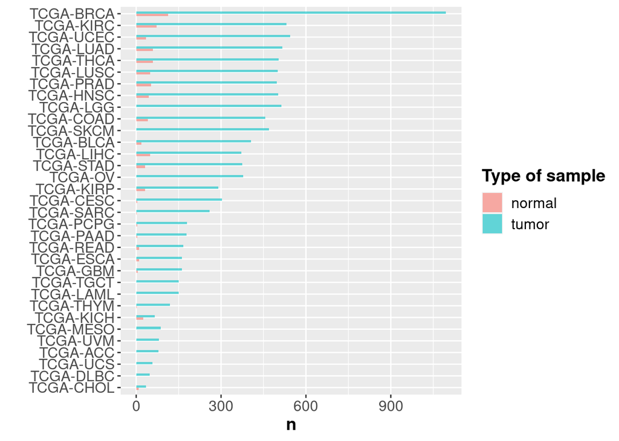

```r
# Plot project IDs
metadata_cases_count_tumor <- metadata_cases_df %>% filter(sample_type_simplified == "tumor") %>% count(project_id)
metadata_cases_count_normal <- metadata_cases_df %>% filter(sample_type_simplified == "normal") %>% count(project_id)
metadata_cases_count_by_sample_type = full_join(metadata_cases_count_tumor %>% rename(tumor=n), metadata_cases_count_normal %>% rename(normal=n), by="project_id") %>% replace(is.na(.), 0) %>% pivot_longer(-project_id, names_to="sample_type_simplified", values_to="n")
metadata_cases_plot_file = '/home/j.aguirreplans/Projects/Scipher/SampleSize/data/out/plots/tcga_num_cases_per_project.png'
metadata_cases_plot <- metadata_cases_count_by_sample_type %>%
  mutate(project_id = fct_reorder(project_id, n)) %>%
  ggplot( aes(x=project_id, y=n, fill=sample_type_simplified)) +
    geom_bar(position="dodge", stat="identity", alpha=.6, width=.4) +
    coord_flip() +
    xlab("") +
    guides(fill=guide_legend(title="Type of sample")) +
    #theme_bw()
    theme(plot.title =  element_text(size = 17, face="bold"), axis.title = element_text(size = 14, face="bold"), axis.text = element_text(size = 12), legend.text = element_text(size = 12), legend.title=element_text(size=14, face="bold"))
ggsave(metadata_cases_plot_file, plot=metadata_cases_plot, type='cairo', dpi = 300, height=8, width = 10)
#ggsave(metadata_cases_plot_file,plot = metadata_cases_plot,type='cairo',dpi = 1200,width = 9000,height = 6000,units = c("px"))

metadata_cases_plot
```

## Data

We read the processed file:

```r
# Define and read data file
if(!(type_counts %in% c("tpm", "reads"))){
  stop("Unknown type of data")
}
tcga_file = paste(output_dir, paste("TCGA_", type_counts, ".csv", sep=""), sep='/')
tcga_df = fread(tcga_file, header=TRUE)
```

The `tcga_df` dataframe contains 11124 columns (samples) and 60660 rows (genes).

```r
tcga_df %<>% rename("Ensembl"="gene_id")
head(tcga_df[1:10,1:5])
```

```
##               Ensembl
## 1: ENSG00000000003.15
## 2:  ENSG00000000005.6
## 3: ENSG00000000419.13
## 4: ENSG00000000457.14
## 5: ENSG00000000460.17
## 6: ENSG00000000938.13
##    88215dd0-5841-44f1-9393-eefd8238cbb3.rna_seq.augmented_star_gene_counts.tsv
## 1:                                                                     54.5637
## 2:                                                                      0.0966
## 3:                                                                     93.9366
## 4:                                                                     13.0767
## 5:                                                                      2.4590
## 6:                                                                      1.3697
##    e74f321c-217f-4bdc-ad17-f132501b5157.rna_seq.augmented_star_gene_counts.tsv
```

[output cut: 20 more lines]

```r
dim(tcga_df)
```

```
## [1] 60660 11124
```

The columns (samples) are actually file names. We select the ones present in the metadata:

```r
metadata_file_names = unique(metadata_df$file_name)
tcga_df = cbind(tcga_df$Ensembl, tcga_df %>% select(all_of(metadata_file_names)))
tcga_df %<>% rename("Ensembl"="V1")
dim(tcga_df)
```

```
## [1] 60660 11124
```

Now it contains 11124 columns (samples) and 60660 rows (genes).

### Gene pre-processing

In the gene expression dataframe, there are 60660 genes in Ensembl notation. We will transform these genes into HGNC gene symbol notation.

First we read the file `multiple_hgnc_dict_set_2022-01-01.txt`, containing gene symbols and their aliases in other notations:

```r
gene_annotations_dir = '/work/ccnr/j.aguirreplans/data/gene_annotations/data/out'
gene_dict_file = paste(gene_annotations_dir, 'multiple_hgnc_dict_set_2022-01-01.txt', sep='/')
gene_dict_df = fread(gene_dict_file) %>% unique()
gene_dict_df = gene_dict_df[!((gene_dict_df$HGNC_Symbol=="")|(gene_dict_df$alias=="")),]
gene_dict_df$HGNC_Symbol = toupper(gene_dict_df$HGNC_Symbol)
gene_dict_df$alias = toupper(gene_dict_df$alias)
gene_dict_df %<>% unique()
head(gene_dict_df)
```

```
##    HGNC_Symbol           alias
## 1:       MT-TF ENSG00000210049
## 2:       MT-TF ENST00000387314
## 3:       MT-TF       MT-TF-201
## 4:     MT-RNR1 ENSG00000211459
## 5:     MT-RNR1 ENST00000389680
## 6:     MT-RNR1     MT-RNR1-201
```

We remove the Ensembl ID part after the “.” in the gene expression dataframe:

```r
tcga_df$Ensembl = sub("\\..*", "", tcga_df$Ensembl)
head(tcga_df[1:5,1:5])
```

```
##            Ensembl
## 1: ENSG00000000003
## 2: ENSG00000000005
## 3: ENSG00000000419
## 4: ENSG00000000457
## 5: ENSG00000000460
##    85336ff5-d423-454d-8edf-bc97af9a5e29.rna_seq.augmented_star_gene_counts.tsv
## 1:                                                                     44.2779
## 2:                                                                      0.0548
## 3:                                                                    121.0119
## 4:                                                                      3.8444
## 5:                                                                      3.6123
##    e04b4f83-7f24-4206-acc5-55ee2317b26f.rna_seq.augmented_star_gene_counts.tsv
## 1:                                                                     29.4381
## 2:                                                                      0.0000
## 3:                                                                    163.0035
## 4:                                                                      2.8120
## 5:                                                                      3.1875
##    6c1a0af0-9db0-410a-a1c0-0088f3a2eab1.rna_seq.augmented_star_gene_counts.tsv
## 1:                                                                     46.5308
## 2:                                                                      1.3162
## 3:                                                                    129.9220
## 4:                                                                      2.9166
## 5:                                                                      8.5027
##    7ff6dbf9-64ae-423b-9d69-9df673b93861.rna_seq.augmented_star_gene_counts.tsv
## 1:                                                                     12.6348
## 2:                                                                      0.0000
## 3:                                                                     89.7465
## 4:                                                                      4.6962
## 5:                                                                     13.1129
```

We use this dataframe to map Ensembl IDs to HGNC symbol IDs:

```r
tcga_df = inner_join(tcga_df, gene_dict_df, by=c("Ensembl"="alias"))
tcga_df = cbind((tcga_df %>% select("Ensembl", "HGNC_Symbol")), (tcga_df %>% select(-"Ensembl", -"HGNC_Symbol"))) %>% unique()
head(tcga_df[1:5,1:5])
```

```
##            Ensembl HGNC_Symbol
## 1: ENSG00000000003      TSPAN6
## 2: ENSG00000000005        TNMD
## 3: ENSG00000000419        DPM1
## 4: ENSG00000000457       SCYL3
## 5: ENSG00000000460    C1ORF112
##    85336ff5-d423-454d-8edf-bc97af9a5e29.rna_seq.augmented_star_gene_counts.tsv
## 1:                                                                     44.2779
## 2:                                                                      0.0548
## 3:                                                                    121.0119
## 4:                                                                      3.8444
## 5:                                                                      3.6123
##    e04b4f83-7f24-4206-acc5-55ee2317b26f.rna_seq.augmented_star_gene_counts.tsv
## 1:                                                                     29.4381
## 2:                                                                      0.0000
## 3:                                                                    163.0035
## 4:                                                                      2.8120
## 5:                                                                      3.1875
##    6c1a0af0-9db0-410a-a1c0-0088f3a2eab1.rna_seq.augmented_star_gene_counts.tsv
## 1:                                                                     46.5308
## 2:                                                                      1.3162
## 3:                                                                    129.9220
## 4:                                                                      2.9166
## 5:                                                                      8.5027
```

```r
dim(tcga_df)
```

```
## [1] 40225 11125
```

Now, we have 40161 unique HGNC symbols mapped to 40045 unique Ensembl IDs from a total of 40225 rows. The problem is that there are Ensembl IDs mapped to the same HGNC code and viceversa. So, we have to do the following procedures: - If an Ensembl ID has multiple HGNC symbols, keep only one symbol - If a HGNC symbol has multiple Ensembl IDs, calculate the median

```r
repeated_ensembl = unique(tcga_df$Ensembl[duplicated(tcga_df$Ensembl)])
length(repeated_ensembl)
```

```
## [1] 178
```

```r
repeated_ensembl_df = tcga_df[tcga_df$Ensembl %in% repeated_ensembl,][,c("Ensembl", "HGNC_Symbol")]
repeated_ensembl_df$HGNC_length = nchar(repeated_ensembl_df$HGNC_Symbol)
repeated_ensembl_df = repeated_ensembl_df[order(Ensembl, HGNC_length),]
head(repeated_ensembl_df)
```

```
##            Ensembl HGNC_Symbol HGNC_length
## 1: ENSG00000002586        CD99           4
## 2: ENSG00000002586        CD99           4
## 3: ENSG00000018607      ZNF806           6
## 4: ENSG00000018607    ZNF285CP           8
## 5: ENSG00000034239        CLXN           4
## 6: ENSG00000034239      EFCAB1           6
```

We keep the smallest symbol, and if not, the first (in alphabetical order):

```r
repeated_ensembl_distinct_df = repeated_ensembl_df %>% distinct(Ensembl, .keep_all = TRUE) %>% select(Ensembl, HGNC_Symbol)
head(repeated_ensembl_distinct_df)
```

```
##            Ensembl HGNC_Symbol
## 1: ENSG00000002586        CD99
## 2: ENSG00000018607      ZNF806
## 3: ENSG00000034239        CLXN
## 4: ENSG00000093134        VNN3
## 5: ENSG00000101898       MCTS2
## 6: ENSG00000124333       VAMP7
```

```r
hgnc_to_remove = repeated_ensembl_df$HGNC_Symbol[!(repeated_ensembl_df$HGNC_Symbol %in% repeated_ensembl_distinct_df$HGNC_Symbol)]
tcga_df %<>% filter(!(HGNC_Symbol %in% hgnc_to_remove))
```

```r
dim(tcga_df)
```

```
## [1] 40082 11125
```

```r
repeated_hgnc = unique(tcga_df$HGNC_Symbol[duplicated(tcga_df$HGNC_Symbol)])
length(repeated_hgnc)
```

```
## [1] 63
```

```r
repeated_hgnc_df = tcga_df[tcga_df$HGNC_Symbol %in% repeated_hgnc,][,c("Ensembl", "HGNC_Symbol")][order(HGNC_Symbol),]
head(repeated_hgnc_df)
```

```
##            Ensembl HGNC_Symbol
## 1: ENSG00000197976     AKAP17A
## 2: ENSG00000197976     AKAP17A
## 3: ENSG00000237801      AMD1P2
## 4: ENSG00000237801      AMD1P2
## 5: ENSG00000196433        ASMT
## 6: ENSG00000196433        ASMT
```

We calculate the median for the HGNC genes with multiple Ensembl IDs:

```r
tcga_df = subset(tcga_df, select=-Ensembl)
repeated_hgnc_aggregated = aggregate(.~HGNC_Symbol, tcga_df[tcga_df$HGNC_Symbol %in% repeated_hgnc,], median)
tcga_df = rbind(tcga_df[!(tcga_df$HGNC_Symbol %in% repeated_hgnc),], repeated_hgnc_aggregated)
dim(tcga_df)
```

```
## [1] 40019 11124
```

```r
tcga_processed_file = paste(output_dir, "TCGA_genes_processed.csv", sep='/')
fwrite(tcga_df, tcga_processed_file, sep='\t')
```

### Sample pre-processing

There are participant_sample_type IDs that are mapped to multiple files. We will merge the participant_sample_type IDs that have multiple file IDs, and substitute the file IDs with participant_sample_type IDs in the data file.

We identify the participant_sample_type IDs with multiple file IDs:

```r
mappings_tcga_df = metadata_df %>% filter(file_name %in% colnames(tcga_df)[-1]) %>% select(file_name, participant_sample_type) %>% unique()
mappings_tcga_duplicated_df = mappings_tcga_df %>% filter(participant_sample_type %in% subset(mappings_tcga_df,duplicated(participant_sample_type))$participant_sample_type)
head(mappings_tcga_duplicated_df)
```

```
##                                                                      file_name
## 1: 7cd8c835-cbce-4aa1-84d0-3ea7d3112630.rna_seq.augmented_star_gene_counts.tsv
## 2: 829d07d7-8a03-4350-8999-4ffd493f6218.rna_seq.augmented_star_gene_counts.tsv
## 3: 34f4f7ab-2d66-4e80-a800-023f8279855e.rna_seq.augmented_star_gene_counts.tsv
## 4: d7094569-100f-4bb1-bd9d-35e0f7485547.rna_seq.augmented_star_gene_counts.tsv
## 5: e1e79392-73f2-4a23-961e-19dc6a315b22.rna_seq.augmented_star_gene_counts.tsv
## 6: 49432779-e2b3-4e36-b1a9-88c7c45854ff.rna_seq.augmented_star_gene_counts.tsv
##    participant_sample_type
## 1:              A13J-tumor
## 2:              A13J-tumor
## 3:              A13J-tumor
## 4:              A0C8-tumor
## 5:              A0C8-tumor
## 6:              A0C8-tumor
```

There are 118 participant_sample_type IDs with multiple file IDs. We calculate the median between the expression of these file IDs.

```r
genes_tcga_df = tcga_df$HGNC_Symbol
tcga_df %<>% select(-HGNC_Symbol) %>% t() %>% as.data.frame()
colnames(tcga_df) = genes_tcga_df
tcga_df = cbind(data.frame(file_name=row.names(tcga_df)), tcga_df)
tcga_df %<>% inner_join(mappings_tcga_df, by=c("file_name"="file_name"))
tcga_df %<>% relocate(file_name, participant_sample_type)
tcga_df = subset(tcga_df, select=-file_name)
tcga_participant_ids_duplicated = tcga_df[tcga_df$participant_sample_type %in% unique(mappings_tcga_duplicated_df$participant_sample_type),]
#participant_ids_aggregated = aggregate(.~participant_sample_type, tcga_participant_ids_duplicated, median)
participant_ids_aggregated = tcga_participant_ids_duplicated %>% group_by(participant_sample_type) %>% summarise(across(everything(), median, na.rm = TRUE)) %>% ungroup() %>% as.data.frame()
tcga_df = rbind(tcga_df[!(tcga_df$participant_sample_type %in% unique(mappings_tcga_duplicated_df$participant_sample_type)),], participant_ids_aggregated)
dim(tcga_df)
```

```
## [1] 10963 40020
```

```r
# We transpose the matrix
genes = colnames((tcga_df %>% select(-participant_sample_type)))
participant_sample_type_ids = tcga_df$participant_sample_type
tcga_df = t(as.matrix((tcga_df %>% select(-participant_sample_type)))) %>% as.data.frame()
colnames(tcga_df) = participant_sample_type_ids
tcga_df = cbind(data.frame(Gene=genes), tcga_df)
```

```r
tcga_processed_file = paste(output_dir, "TCGA_genes_and_samples_processed.csv", sep='/')
fwrite(tcga_df, tcga_processed_file, sep='\t')
```

The processed `tcga_df` dataframe contains 10963 columns (participant_sample_type IDs) and 40019 rows (genes).

```r
head(tcga_df[1:10,1:5])
```

```
##              Gene A2I6-tumor A6TK-tumor A78L-tumor AA84-tumor
## TSPAN6     TSPAN6    44.2779    29.4381    46.5308    12.6348
## TNMD         TNMD     0.0548     0.0000     1.3162     0.0000
## DPM1         DPM1   121.0119   163.0035   129.9220    89.7465
## SCYL3       SCYL3     3.8444     2.8120     2.9166     4.6962
## C1ORF112 C1ORF112     3.6123     3.1875     8.5027    13.1129
## FGR           FGR     2.8234    14.7796     2.8722     1.6578
```